# R tutorial - basics

Wooyong Lee

# Basics

### Value assignment

Most task of R begins with creating a storage space and assigning data into it.

In programming languages we call the storage space as **variable** and the data as **value**.

Values are categorized into several types, such as `integer`, `real number`, `character string`, `real vector`, `real matrix`, etc.

In R, a variable can store any type of value. To store a real number to a variable, use `<-` operator:

```r
abc <- 2.5
```

To view stored value, type the variable name:

```r
abc
```

```
## [1] 2.5
```

The `<-` operator requires typing two characters, `<` and `-`. In RStudio you can use the shortcut `Alt`+`-` to type `<-`. You may also use the `=` operator:

```r
abc = 2.5
abc
```

```
## [1] 2.5
```

However, there will be occasions where `=` operator does not work while `<-` always works.

To assign a vector, which we also call **array**, use `c()` function:

```r
abc = c(1,2,3,4,5)
abc
```

```
## [1] 1 2 3 4 5
```

To assign an integer sequence, use `:` operator:

```r
abc = 1:5
abc
```

```
## [1] 1 2 3 4 5
```

```r
abc = 3:(-2)
abc
```

```
## [1]  3  2  1  0 -1 -2
```

To assign a repeated array, use `rep` function:

```r
abc = rep(2, 5)
abc
```

```
## [1] 2 2 2 2 2
```

```r
abc = rep(c(1,2,3), 5)
abc
```

```
##  [1] 1 2 3 1 2 3 1 2 3 1 2 3 1 2 3
```

To assign an equispaced array, use `seq` function:

```r
abc = seq(from=0, to=1, by=0.1)
abc
```

```
##  [1] 0.0 0.1 0.2 0.3 0.4 0.5 0.6 0.7 0.8 0.9 1.0
```

```r
abc = seq(from=0, to=1, length=11)
abc
```

```
##  [1] 0.0 0.1 0.2 0.3 0.4 0.5 0.6 0.7 0.8 0.9 1.0
```

To assign a matrix, use `matrix` function:

```r
abc = matrix(0, nrow=3, ncol=2)
abc
```

```
##      [,1] [,2]
## [1,]    0    0
## [2,]    0    0
## [3,]    0    0
```

```r
abc = matrix(1:6, nrow=3, ncol=2)
abc
```

```
##      [,1] [,2]
## [1,]    1    4
## [2,]    2    5
## [3,]    3    6
```

```r
abc = matrix(1:6, nrow=3, ncol=2, byrow=TRUE)
abc
```

```
##      [,1] [,2]
## [1,]    1    2
## [2,]    3    4
## [3,]    5    6
```

```r
abc = matrix(1:3, nrow=3, ncol=2)
abc
```

```
##      [,1] [,2]
## [1,]    1    1
## [2,]    2    2
## [3,]    3    3
```

To assign multidimensional array, use `array` function:

```r
abc = array(0, dim=c(3,2,4))
abc
```

```
## , , 1
##
##      [,1] [,2]
## [1,]    0    0
## [2,]    0    0
## [3,]    0    0
##
## , , 2
##
##      [,1] [,2]
## [1,]    0    0
## [2,]    0    0
## [3,]    0    0
##
## , , 3
##
##      [,1] [,2]
## [1,]    0    0
## [2,]    0    0
## [3,]    0    0
##
## , , 4
##
##      [,1] [,2]
## [1,]    0    0
## [2,]    0    0
## [3,]    0    0
```

### Arithmetic operators

R considers real numbers, vectors and matrices as `numeric` variables, for which you can apply arithmetic operators.

```r
abc = 2.5
def = abc + 3
def
```

```
## [1] 5.5
```

If you don’t specify storing variable, R simply prints the result onto the screen.

```r
abc + 3
```

```
## [1] 5.5
```

For vector and matrices, R applies Arithmetic operators element-wise.

```r
abc = matrix(1:6,  nrow=3, ncol=2)
def = matrix(7:12, nrow=3, ncol=2)
abc
```

```
##      [,1] [,2]
## [1,]    1    4
## [2,]    2    5
## [3,]    3    6
```

```r
def
```

```
##      [,1] [,2]
## [1,]    7   10
## [2,]    8   11
## [3,]    9   12
```

```r
2 * abc
```

```
##      [,1] [,2]
## [1,]    2    8
## [2,]    4   10
## [3,]    6   12
```

```r
- def
```

```
##      [,1] [,2]
## [1,]   -7  -10
## [2,]   -8  -11
## [3,]   -9  -12
```

```r
abc + def
```

```
##      [,1] [,2]
## [1,]    8   14
## [2,]   10   16
## [3,]   12   18
```

```r
abc * def
```

```
##      [,1] [,2]
## [1,]    7   40
## [2,]   16   55
## [3,]   27   72
```

To apply mathematical matrix multiplication, use `%*%` operator:

```r
abc = matrix(1:6,  nrow=3, ncol=2)
ghi = matrix(1:4,  nrow=2, ncol=2)
abc %*% ghi
```

```
##      [,1] [,2]
## [1,]    9   19
## [2,]   12   26
## [3,]   15   33
```

The `%%` operator performs `mod` operation:

```r
5 %% 2
```

```
## [1] 1
```

### Accessing entries of arrays and matrices

To access entries, specify row and column numbers within `[]` bracket. Row and column indices begin with `1`.

```r
mat = matrix(1:6, nrow=3, ncol=2)
mat
```

```
##      [,1] [,2]
## [1,]    1    4
## [2,]    2    5
## [3,]    3    6
```

```r
mat[1,1]
```

```
## [1] 1
```

```r
mat[3,2]
```

```
## [1] 6
```

There is no zero index:

```r
mat[0,1]
```

```
## integer(0)
```

To access row and columns:

```r
mat[3,]
```

```
## [1] 3 6
```

```r
mat[,2]
```

```
## [1] 4 5 6
```

To access submatrices:

```r
mat[c(1,2),]
```

```
##      [,1] [,2]
## [1,]    1    4
## [2,]    2    5
```

A useful trick:

```r
mat[c(1,3,3,3,2,1,3),]
```

```
##      [,1] [,2]
## [1,]    1    4
## [2,]    3    6
## [3,]    3    6
## [4,]    3    6
## [5,]    2    5
## [6,]    1    4
## [7,]    3    6
```

### Strings

An R variable can store English words and sentences, which we call **string**.

To assign a string, write English within `""`.

```r
abc = "Apple"
def = "Orange"
```

To combine strings into one, use `paste` function:

```r
paste(abc, def)
```

```
## [1] "Apple Orange"
```

```r
paste(abc, def, sep = "+")
```

```
## [1] "Apple+Orange"
```

```r
paste(abc, def, sep = "")
```

```
## [1] "AppleOrange"
```

You can use `paste` with numeric variables and arrays:

```r
paste(abc, 1:5, sep = "")
```

```
## [1] "Apple1" "Apple2" "Apple3" "Apple4" "Apple5"
```

A useful option for `paste` is `collapse`:

```r
abc = 1:5
abc
```

```
## [1] 1 2 3 4 5
```

```r
paste(abc, collapse = "+")
```

```
## [1] "1+2+3+4+5"
```

### Logical operators

R reserved two variable names, `TRUE` and `FALSE`, for logical operations. You cannot overwrite these two variable names:

```r
TRUE <- 1
```

```
## Error in TRUE <- 1: invalid (do_set) left-hand side to assignment
```

Here are some examples of logical operators:

- `>`, `<`, `>=`, `<=` : compares values of two sides
- `==` : checks if the two sides are equal
- `!=` : checks if the two sides are not equal
- `%in%`: check if the left-hand side appears in the right-hand side

These operators work in the same way as arithmetic operators work, except that the results are either `TRUE` or `FALSE`.

Below example shows that the way logical operations work are similar to that of arithmetic operations.

```r
3 > 2
```

```
## [1] TRUE
```

```r
c(2,3,4) == c(3,3,4)
```

```
## [1] FALSE  TRUE  TRUE
```

```r
3 != c(3,3,4)
```

```
## [1] FALSE FALSE  TRUE
```

```r
3 %in% c(1,2,3,4,5)
```

```
## [1] TRUE
```

`TRUE` and `FALSE` are variables themselves. `TRUE` equals `1` and `FALSE` equals `0`.

```r
TRUE == 1
```

```
## [1] TRUE
```

```r
FALSE == 0
```

```
## [1] TRUE
```

This means that you can treat a result of logical operation as 1 or 0 and perform arithmetic operations on it.

```r
(3 > 2) * 2 + 1
```

```
## [1] 3
```

### Custom functions

In previous sections we used functions such as `c`, `seq`, `matrix` and `paste`.

You may write your own function in R to efficiently perform repeated tasks.

To write a custom function, assign **function** to a **variable**:

```r
add = function(x,y) {
  return(x+y)
}
square = function(x) {
  return(x^2)
}
```

The `return` keyword may be omitted, in which case R returns what is **printed** in the last line.

```r
square_noReturnStatement = function(x) {
  x^2
}
```

To call a function, write the variable name and put arguments inside the `()` bracket.

```r
abc = 3
add(x=abc, y=2)
```

```
## [1] 5
```

```r
square(x=3)
```

```
## [1] 9
```

```r
square_noReturnStatement(x=3)
```

```
## [1] 9
```

You may omit labels:

```r
add(abc,2)
```

```
## [1] 5
```

Similar to arithmetic operators, you may assign the returned value to a variable.

```r
result = square(abc)
result
```

```
## [1] 9
```

R considers functions as a **variable type**, which means that if you overwrite the function variable with a real number then the function is lost.

```r
# for now, a function is assigned to the variable "add"
add
```

```
## function(x,y) {
##   return(x+y)
## }
## <bytecode: 0x0000000014884018>
```

```r
# we know it works as a function
add(abc, 2)
```

```
## [1] 5
```

```r
# let's assign a real number to "add"
add = 3.5
add
```

```
## [1] 3.5
```

```r
# "add" is no longer a function
add(abc, 2)
```

```
## Error in add(abc, 2): could not find function "add"
```

### data.frame

`data.frame` is a variable type that handles datasets. You can think of it as an enhancement of `matrix`.

To create a `data.frame`, use `data.frame` function:

```r
ctrs = c("U.S.", "Canada", "Mexico")
pops = c(318.9, 35.16, 122.3)

df = data.frame(Country=ctrs, Population=pops)
df
```

```
##   Country Population
## 1    U.S.     318.90
## 2  Canada      35.16
## 3  Mexico     122.30
```

You can access `data.frame` using `[]` bracket like `matrix`:

```r
df[3,2]
```

```
## [1] 122.3
```

Being an enhancement of `matrix`, you can also access a column by its name using money symbol:

```r
df$Population
```

```
## [1] 318.90  35.16 122.30
```

Also, there are functions that applies to `data.frame` and not `matrix`. One of such functions is `subset`:

```r
subDF = subset(df, Population >= 100)
subDF
```

```
##   Country Population
## 1    U.S.      318.9
## 3  Mexico      122.3
```

```r
subDF = subset(df, Population >= 100, select = c("Country"))
subDF
```

```
##   Country
## 1    U.S.
## 3  Mexico
```

### data.table

`data.table` is an enhancement of `data.frame`, developed by one of the contributors of R community.

R is a free open-source program, and there are contributors that adds functionality to R. To use the functionality, you need to install a **package**, which is basically a collection of functions.

To use `data.table`, you need to install a **data.table** package. To install it, type:

```r
install.packages("data.table")
```

Note that you give the name of the package as a string. This command downloads and installs a package from the R online database known as CRAN.

After you installed the package, you can load it using:

```r
library(data.table)
```

You can create a `data.table` object in a way similar to `data.frame`:

```r
ctrs
```

```
## [1] "U.S."   "Canada" "Mexico"
```

```r
pops
```

```
## [1] 318.90  35.16 122.30
```

```r
dt = data.table(Country=ctrs, Population=pops)
dt
```

```
##    Country Population
## 1:    U.S.     318.90
## 2:  Canada      35.16
## 3:  Mexico     122.30
```

You can transform `data.frame` into `data.table` using `as.data.table` function:

```r
df
```

```
##   Country Population
## 1    U.S.     318.90
## 2  Canada      35.16
## 3  Mexico     122.30
```

```r
class(df)
```

```
## [1] "data.frame"
```

```r
dt = as.data.table(df)
dt
```

```
##    Country Population
## 1:    U.S.     318.90
## 2:  Canada      35.16
## 3:  Mexico     122.30
```

```r
class(dt)
```

```
## [1] "data.table" "data.frame"
```

As an enhancement, `data.table` has additional features not present in `data.frame`. For example, it allows subsetting using `[]` bracket:

```r
dt[Population >= 100]
```

```
##    Country Population
## 1:    U.S.      318.9
## 2:  Mexico      122.3
```

```r
dt[Population >= 100, .(Country)]
```

```
##    Country
## 1:    U.S.
## 2:  Mexico
```

For more information, visit https://github.com/Rdatatable/data.table/wiki/Getting-started, which is an webpage created by the author of `data.table`.

### list

`list` is a variable type that can store other variables (sub-variables) within itself. It is created by the `list` function:

```r
abc = list(a=3, b="String", c=123.456)
```

To access the sub-variables within a list, call them using money symbol:

```r
abc$a
```

```
## [1] 3
```

```r
abc$b
```

```
## [1] "String"
```

```r
abc$c
```

```
## [1] 123.456
```

`list` can store any variable type: functions, matrices, list inside a list, and so on.

The following example stores various model primitives of a matching model in labor economics.

```r
# model primitives
model = list(
  r = 0.05, # interest rate
  s = 0.02, # separation rate
  matchFunc = function(u,v) { 0.4 * u^0.5 * v^0.5 }, # matching function
  b = 0, # unemployment benefit
  c = 0, # cost of vacancy
  alpha = 0.5, # bargaining power
  prodFunc = function(x,y) { (x^(-2) + y^(-2))^(1/(-2)) + 0.2 } # production function
)
```

You can call a function inside the list in a usual way:

```r
model$prodFunc(1,2)
```

```
## [1] 1.094427
```

If you omit the sub-variable names when creating a list, R assigns serial numbers to the variables.

```r
abc = list(3, "String", 123.456)
abc
```

```
## [[1]]
## [1] 3
##
## [[2]]
## [1] "String"
##
## [[3]]
## [1] 123.456
```

To access elements using serial numbers, use the double bracket `[[]]`:

```r
abc[[1]]
```

```
## [1] 3
```

```r
abc[[2]]
```

```
## [1] "String"
```

```r
abc[[3]]
```

```
## [1] 123.456
```

### Syntax

R offers various syntax that faciliates operations. Here I introduce two most frequently used syntax, `if` and `for`.

`if` syntax allows to perform different operations depending on if the criterion is `TRUE` or `FALSE`, or if the criterion is nonzero or zero.

```r
isNonnegative = function(x) {
  if(x >= 0) {
    return("Yes")
  } else {
    return("No")
  }
}

isNonnegative(3)
```

```
## [1] "Yes"
```

```r
isNonnegative(2)
```

```
## [1] "Yes"
```

```r
isNonzero = function(x) {
  if(x) {
    return("Yes")
  } else {
    return("No")
  }
}

isNonnegative(3)
```

```
## [1] "Yes"
```

```r
isNonnegative(0)
```

```
## [1] "Yes"
```

`for` syntax allows to repeat operations with different variable values. It is often used as a sequential loop in which you perform operations sequentially.

Below is a canonical usage of `for` loop, which is a loop over natural numbers.

```r
for(i in 1:4) {
  print(i)
}
```

```
## [1] 1
## [1] 2
## [1] 3
## [1] 4
```

```r
sum = 0
for(i in 1:4) {
  sum = sum + i
}
sum
```

```
## [1] 10
```

However, `for` syntax can be used for any type of array:

```r
greekLetterArray = c("Alpha", "Beta", "Gamma", "Delta")
for(greekLetter in greekLetterArray) {
  print(greekLetter)
}
```

```
## [1] "Alpha"
## [1] "Beta"
## [1] "Gamma"
## [1] "Delta"
```

# ggplot2 package

### Basics

`ggplot2` package faciliates creating various plots.

To introduce functionality of `ggplot2`, let’s use `mtcars` dataset in the `datasets` package, which is preinstalled with R.

```r
library(datasets)
print(as.data.table(mtcars))
```

```
##      mpg cyl  disp  hp drat    wt  qsec vs am gear carb
##  1: 21.0   6 160.0 110 3.90 2.620 16.46  0  1    4    4
##  2: 21.0   6 160.0 110 3.90 2.875 17.02  0  1    4    4
##  3: 22.8   4 108.0  93 3.85 2.320 18.61  1  1    4    1
##  4: 21.4   6 258.0 110 3.08 3.215 19.44  1  0    3    1
##  5: 18.7   8 360.0 175 3.15 3.440 17.02  0  0    3    2
##  6: 18.1   6 225.0 105 2.76 3.460 20.22  1  0    3    1
##  7: 14.3   8 360.0 245 3.21 3.570 15.84  0  0    3    4
##  8: 24.4   4 146.7  62 3.69 3.190 20.00  1  0    4    2
##  9: 22.8   4 140.8  95 3.92 3.150 22.90  1  0    4    2
## 10: 19.2   6 167.6 123 3.92 3.440 18.30  1  0    4    4
## 11: 17.8   6 167.6 123 3.92 3.440 18.90  1  0    4    4
## 12: 16.4   8 275.8 180 3.07 4.070 17.40  0  0    3    3
## 13: 17.3   8 275.8 180 3.07 3.730 17.60  0  0    3    3
## 14: 15.2   8 275.8 180 3.07 3.780 18.00  0  0    3    3
```

[output cut: 19 more lines]

To install `ggplot2`:

```r
install.packages("ggplot2")
```

Let’s start from drawing a scatterplot:

```r
library(ggplot2)
ggplot(data=mtcars) + geom_point(aes(x=wt,y=mpg))
```

[output not shown]

A common syntax for drawing plots using `ggplot2` is:

- first designate a dataset that you want to use for plotting: `ggplot(data=mtcars)`
- then specify plotting options with a `+`

In the above, `geom_point` tells that you will draw a scatterplot.

The `aes` keyword within `geom_point` tells which variables become the x axis and the y axis of the plot. `aes` is an abbreviation for aesthetics.

You may specify more plotting options using `+`. Below not only draws a scatterplot but also specifies labels of the x and the y axes.

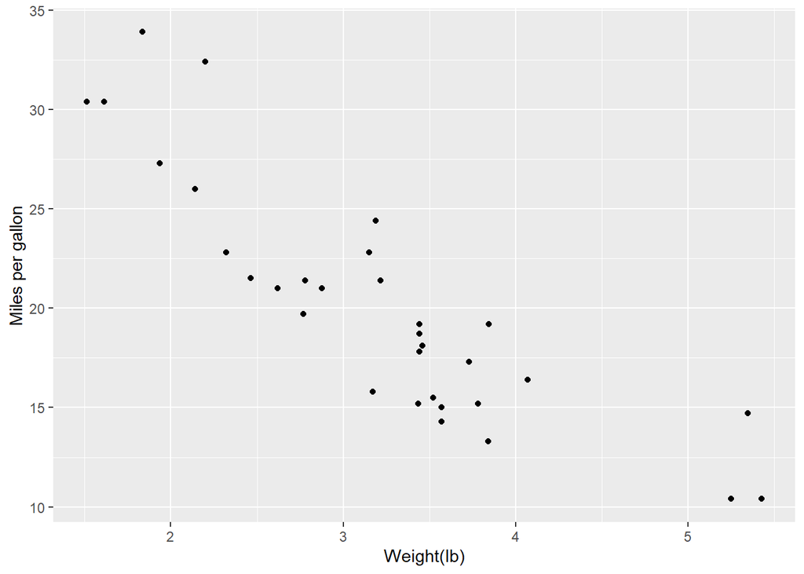

```r
ggplot(data=mtcars) + geom_point(aes(x=wt,y=mpg)) + xlab("Weight(lb)") + ylab("Miles per gallon")
```

You don’t need to specify all options at once. You may save the plot to a variable and then add options to it.

```r
gg = ggplot(data=mtcars) + geom_point(aes(x=wt,y=mpg))
gg
```

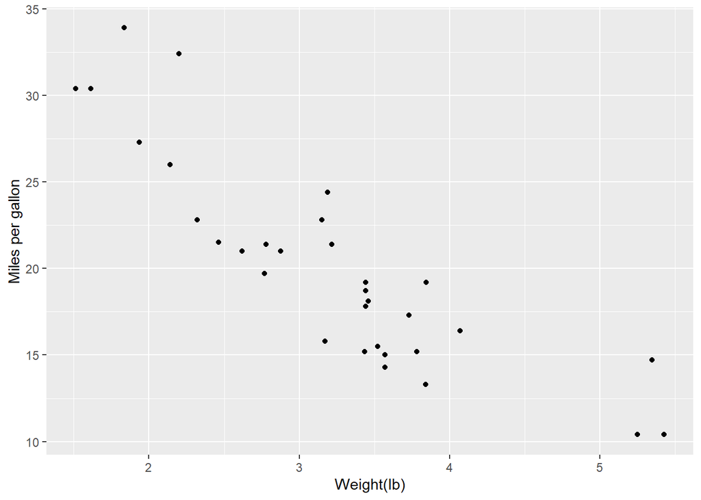

```r
gg + xlab("Weight(lb)") + ylab("Miles per gallon")
```

You may use the `aes` keyword when initializing `ggplot`.

```r
gg = ggplot(data=mtcars, aes(x=wt,y=mpg))
gg + geom_point()
```

[output not shown]

More options for aesthetics:

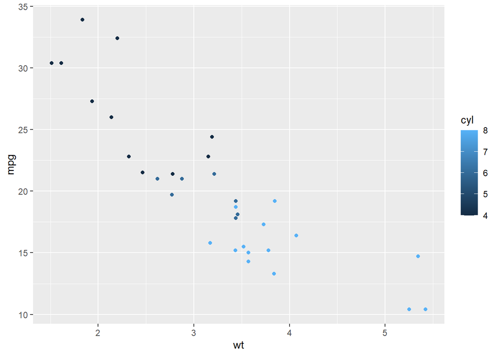

```r
# add colors according to the value of cyl
ggplot(data=mtcars) + geom_point(aes(x=wt,y=mpg,color=cyl))
```

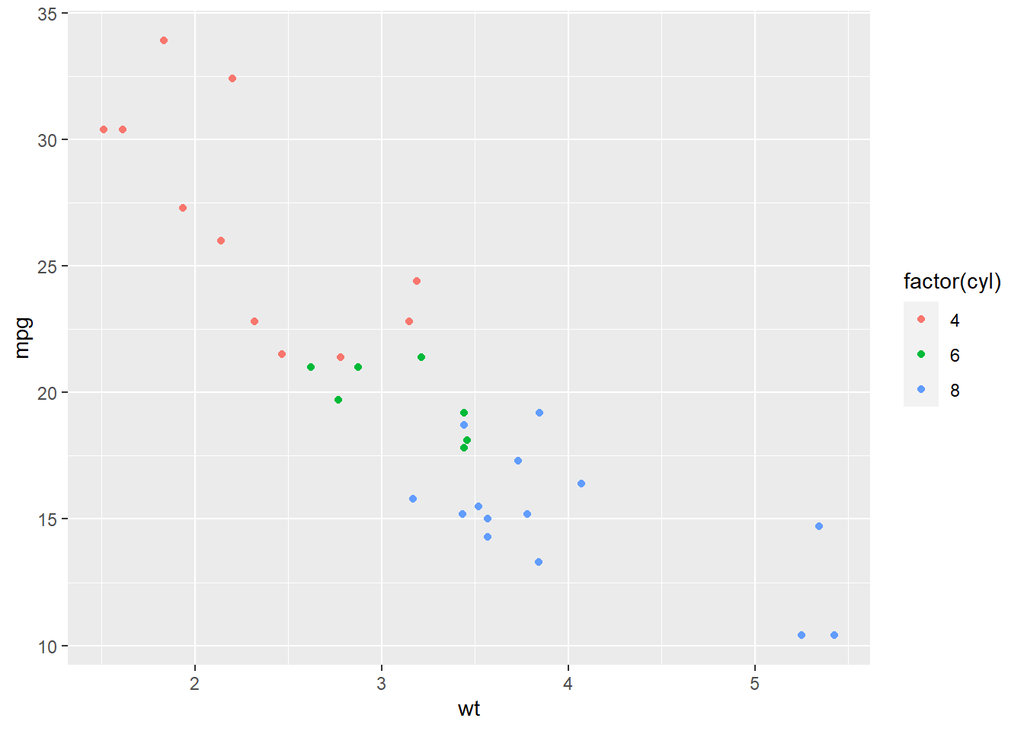

```r
# the function "factor" changes real numbers into categorical variables.
ggplot(data=mtcars) + geom_point(aes(x=wt,y=mpg,color=factor(cyl)))
```

To learn about other options for scatterplot and how to draw other plots, refer to `ggplot2`’s online documentation https://ggplot2.tidyverse.org/reference/index.html.

For example, take a look at https://ggplot2.tidyverse.org/reference/geom_point.html for various options of `geom_point`.

For one-page summary of what `ggplot2` does, check **Help -> Cheatsheets -> Data Visualization with ggplot2** from RStudio.

### theme

You may feel that fonts and legends of `ggplot2` are too small.

To change the font size, you need to modify the settings of ggplot2.

You can do it for each plot by `+ theme(...)` (see online documentation https://ggplot2.tidyverse.org/reference/theme.html).

To permanently change the theme, use the `theme_update` function:

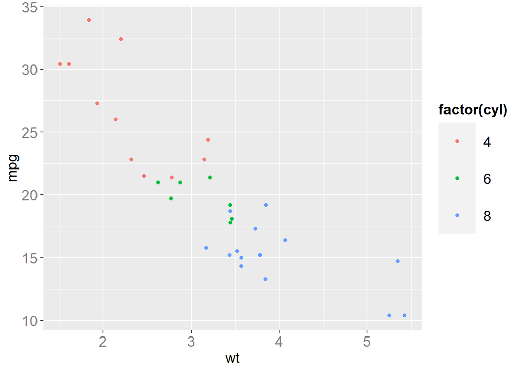

```r
# enlarges ggplot2 font and legend
theme_update(axis.text=element_text(colour="grey50",size=14),
             axis.title=element_text(size=14),
             strip.text=element_text(size=14), # these three lines are for larger axes labels and annotations
             legend.position="right", # this line specifies position of the legend
             legend.key.size=grid::unit(2.5,"lines"),
             legend.title=element_text(size=14,face="bold"),
             legend.text=element_text(size=14)) # these three lines are for larger legend texts

ggplot(data=mtcars) + geom_point(aes(x=wt,y=mpg,color=factor(cyl)))
```

### Saving the plot

`ggsave` function saves the last displayed plot as a file.

You may specify the file extension in it, which means that you can specify how the plot is saved. I recommend you **do not** save in a bitmap image such as `.jpg`, `.png` or `.bmp` because they do not scale up or down well.

I recommend saving in a vector image such as `.pdf`.

```r
# the basic command
ggsave("myplot.pdf")
# you can also specify the size
ggsave("myplot.pdf", width=8, height=5)
```

The file will be saved in your **working directory**. Before saving the file, specify your working directory using the `setwd` function.

```r
setwd("C:/GoogleDrive/MyWorkingDirectory/")
```

### More examples

We finish by looking at more `geom_xxx` functions. Google `geom_xxx ggplot2` and find the link to ggplot2 online documentation for more examples.

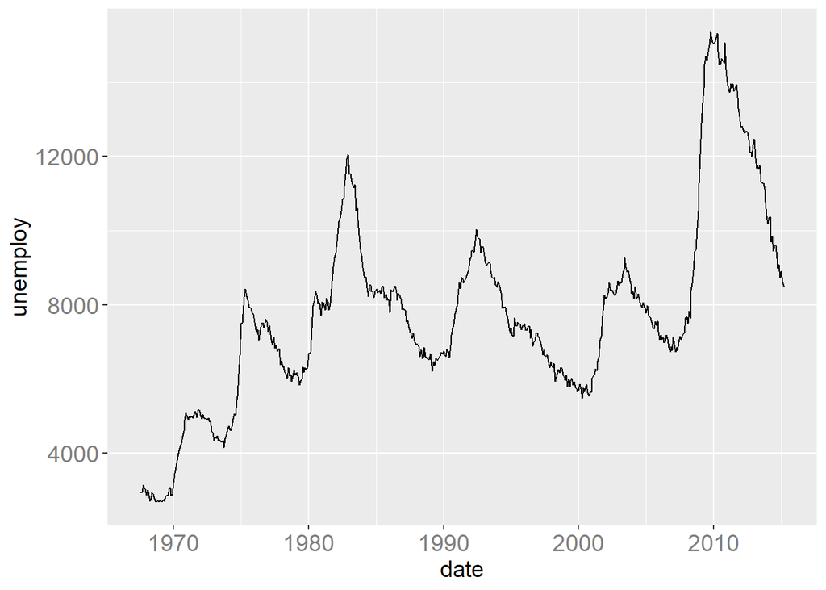

```r
ggplot(data=economics) + geom_line(aes(x=date, y=unemploy))
```

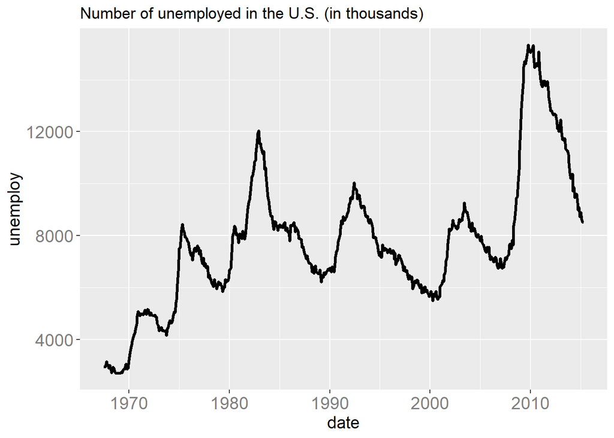

```r
gg = ggplot(data=economics) + geom_line(aes(x=date, y=unemploy), size=1.2)
gg + ggtitle("Number of unemployed in the U.S. (in thousands)")
```

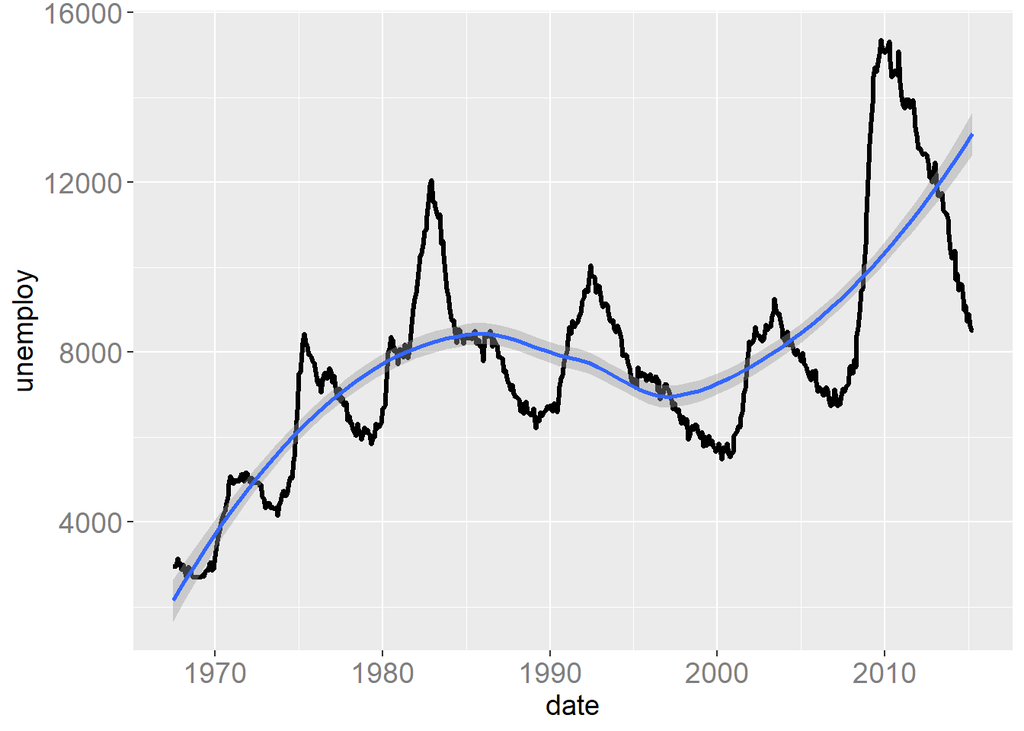

```r
gg + geom_smooth(aes(x=date,y=unemploy))
```

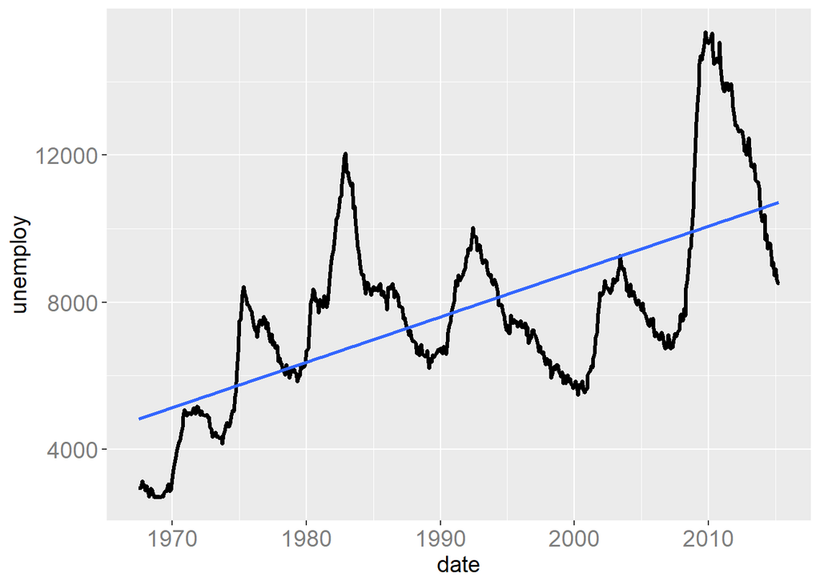

```r
gg + geom_smooth(aes(x=date,y=unemploy), method="lm", se=FALSE)
```

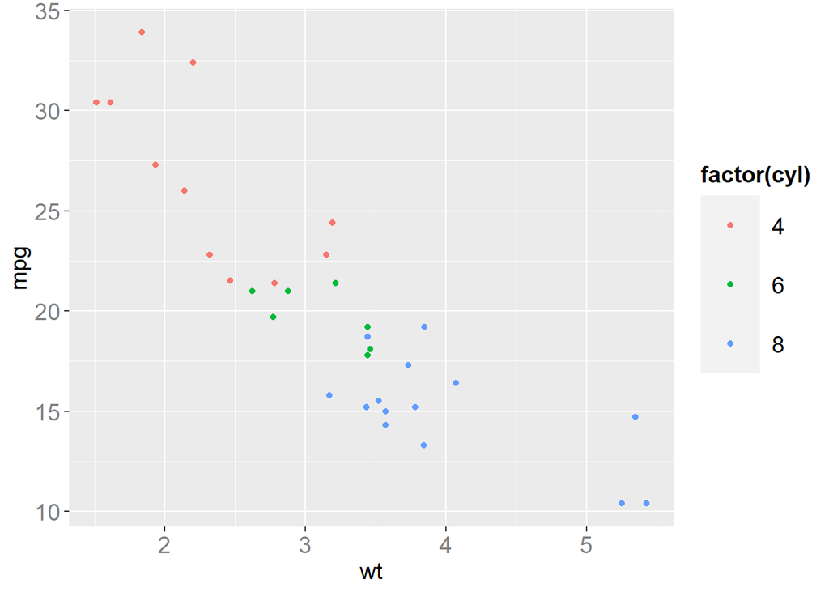

```r
gg = ggplot(data=mtcars) + geom_point(aes(x=wt,y=mpg,color=factor(cyl)))
gg
```

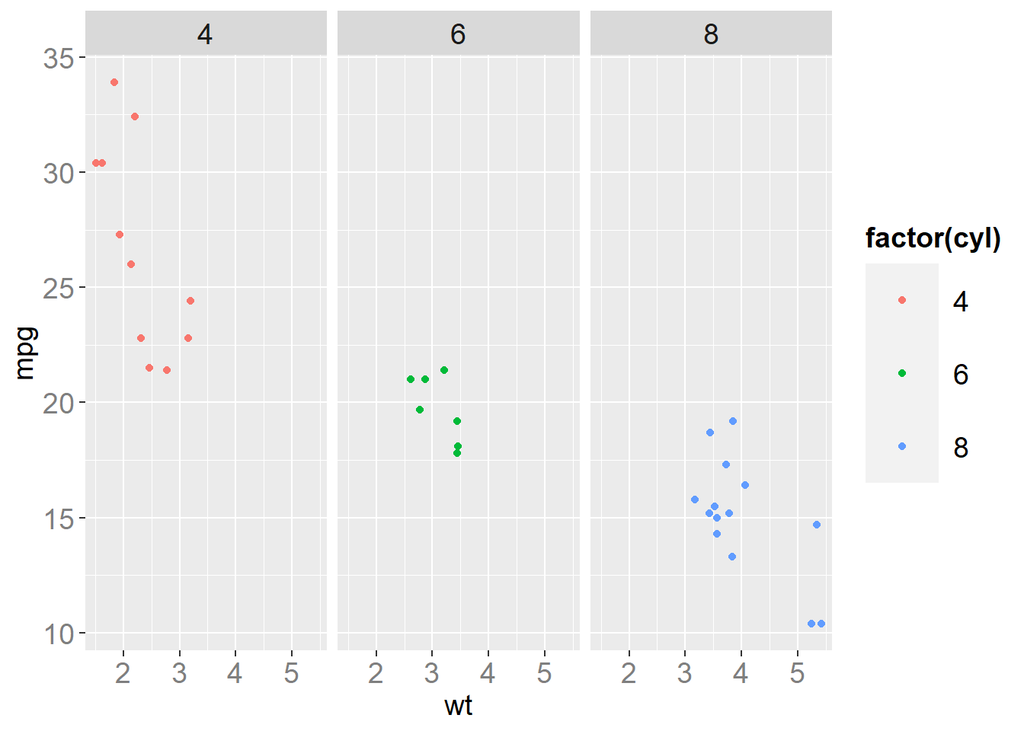

```r
gg + facet_grid(. ~ cyl)
```

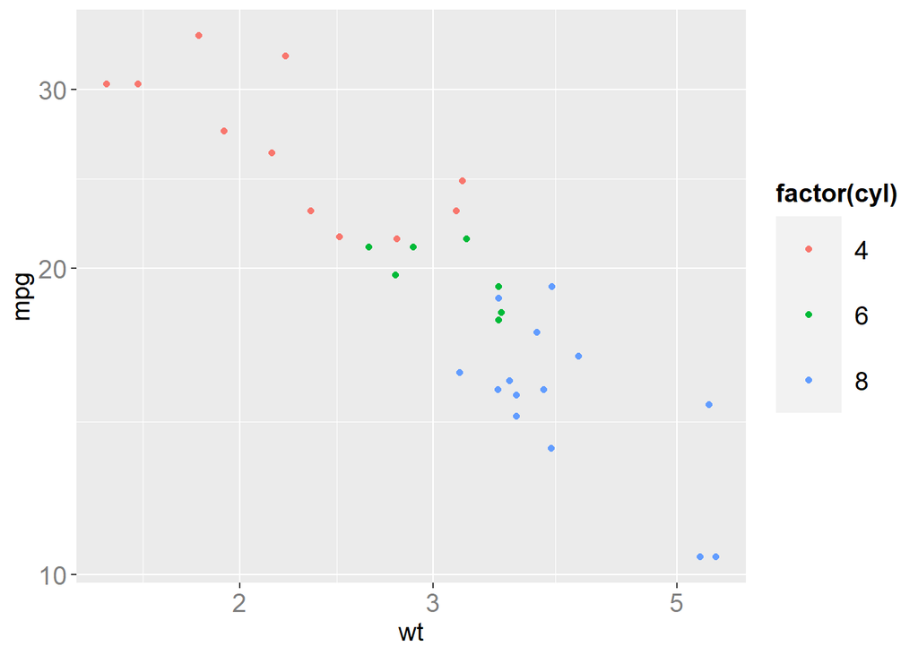

```r
gg + scale_x_log10() + scale_y_log10()
```

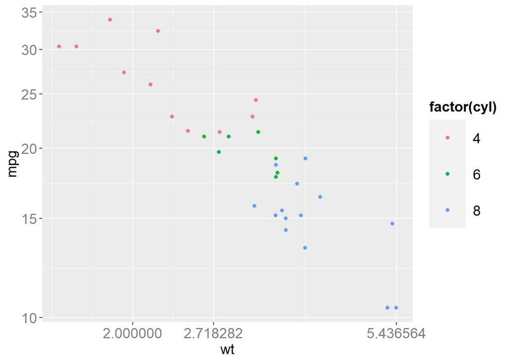

```r
gg + scale_x_continuous(trans = "log") + scale_y_continuous(trans = "log")
```

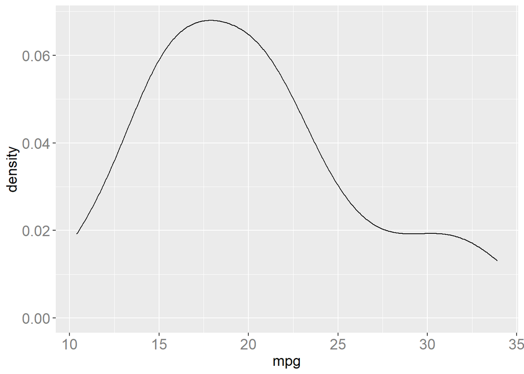

```r
gg = ggplot(data=mtcars)

gg + geom_density(aes(x=mpg))
```

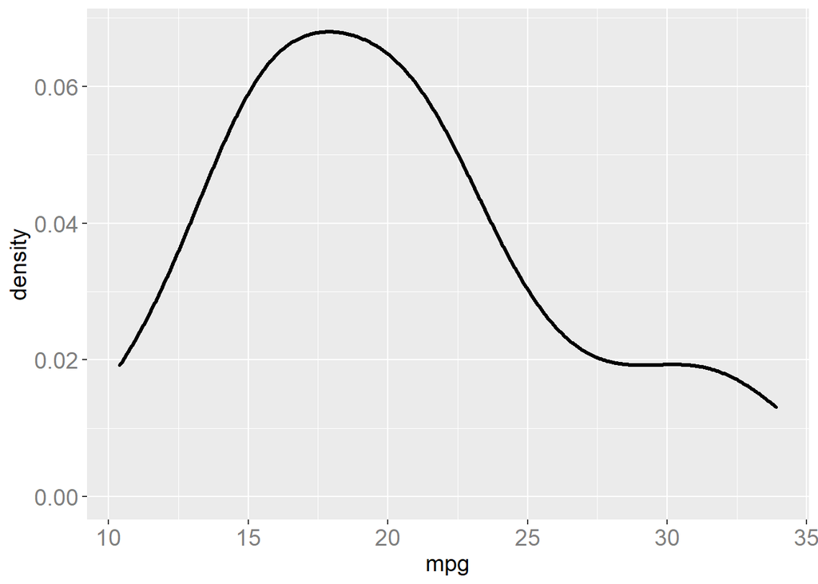

```r
gg + geom_density(aes(x=mpg), size=1.2)
```

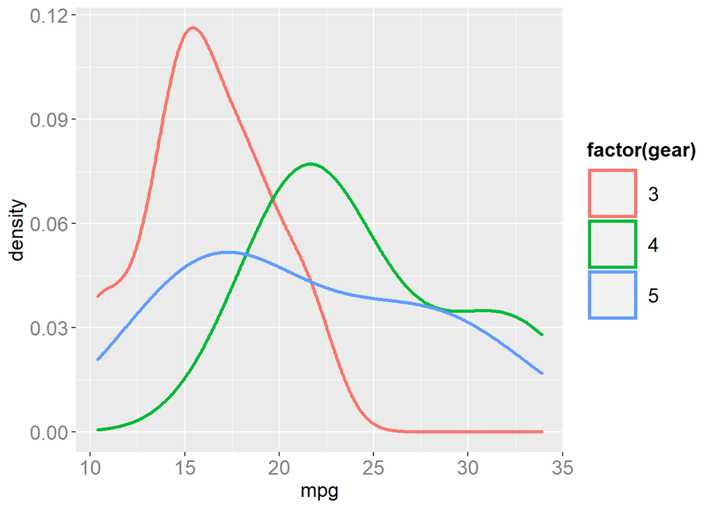

```r
gg + geom_density(aes(x=mpg, color=factor(gear)), size=1.2)
```

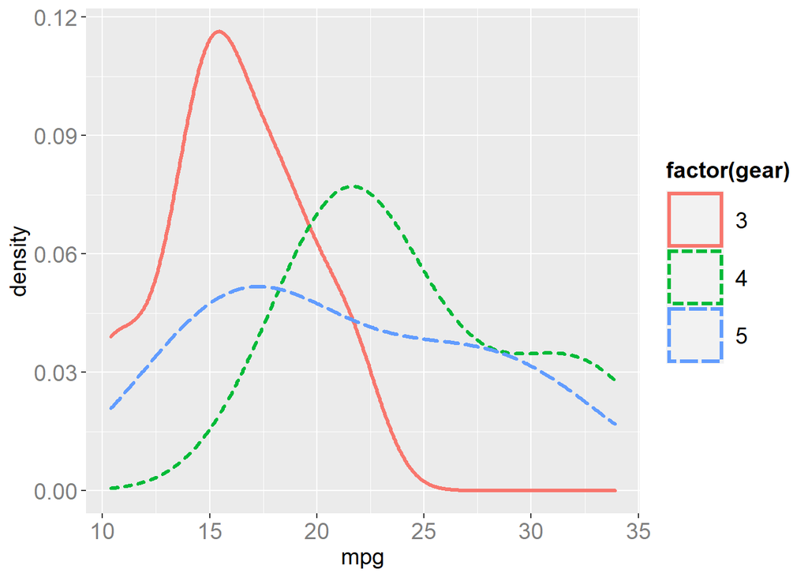

```r
gg + geom_density(aes(x=mpg, color=factor(gear), linetype=factor(gear)), size=1.2)
```

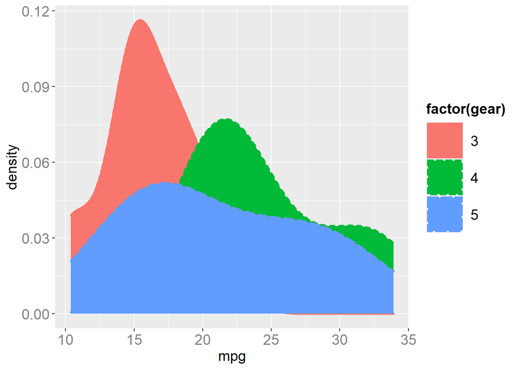

```r
gg + geom_density(aes(x=mpg, color=factor(gear), linetype=factor(gear), fill=factor(gear)), size=1.2)
```

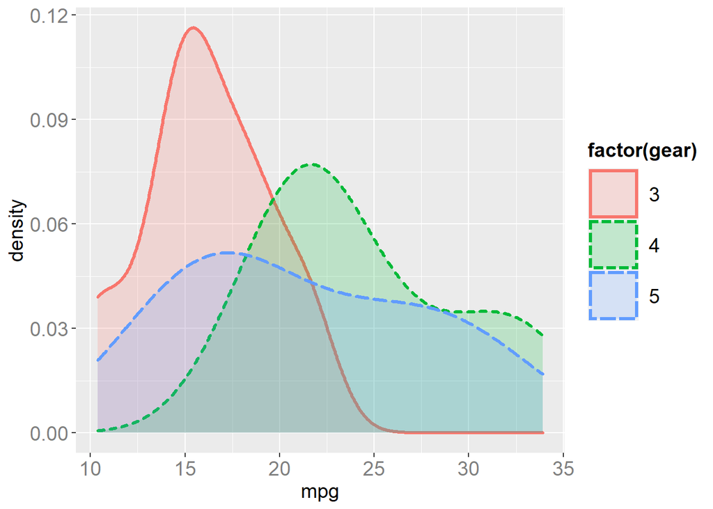

```r
gg + geom_density(aes(x=mpg, color=factor(gear), linetype=factor(gear), fill=factor(gear)), size=1.2, alpha=0.2)
```

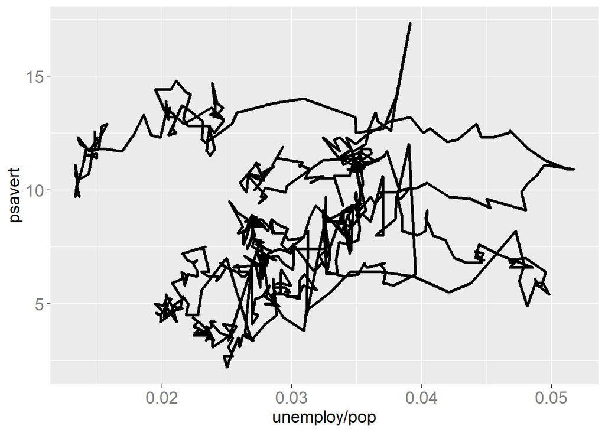

```r
gg = ggplot(data=economics) + geom_path(aes(x=unemploy/pop, y=psavert), size=1.2)
gg
```

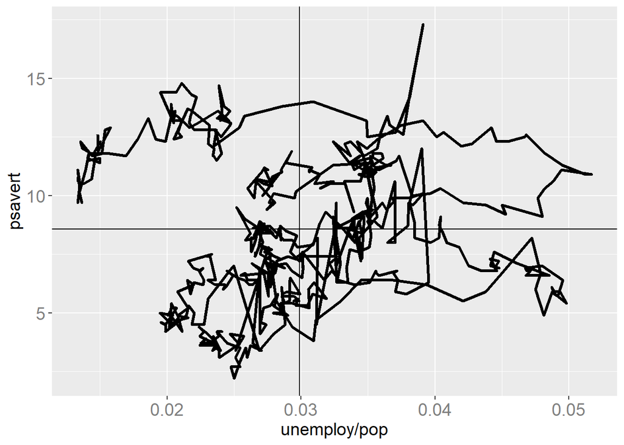

```r
# "geom_hline" does the same thing as "geom_abline" with slope=0.
gg + geom_abline(intercept = mean(economics$psavert), slope = 0) + geom_vline(xintercept = mean(economics$unemploy/(economics$pop)))
```